# Data Cleaning and Exploratory Data Analysis

#### Cleaning our data

1. Check for missing values

```r
colSums(is.na(df))
```

```
Daily.Time.Spent.on.Site                      Age              Area.Income
                       0                        0                        0
    Daily.Internet.Usage            Ad.Topic.Line                     City
                       0                        0                        0
                  Gender                  Country                Timestamp
                       0                        0                        0
           Clicked.on.Ad
                       0
```

There are no missing values in our columns

2. Check for duplicates

```r
#sum(duplicated(df))

sum(duplicated(df))
```

```
[1] 0
```

There are no duplicated values

```r
  str(df)
```

```
'data.frame':   1000 obs. of  10 variables:
 $ Daily.Time.Spent.on.Site: num  69 80.2 69.5 74.2 68.4 ...
 $ Age                     : int  35 31 26 29 35 23 33 48 30 20 ...
 $ Area.Income             : num  61834 68442 59786 54806 73890 ...
 $ Daily.Internet.Usage    : num  256 194 236 246 226 ...
 $ Ad.Topic.Line           : chr  "Cloned 5thgeneration orchestration" "Monitored national standardization" "Organic bottom-line service-desk" "Triple-buffered reciprocal time-frame" ...
 $ City                    : chr  "Wrightburgh" "West Jodi" "Davidton" "West Terrifurt" ...
 $ Gender                  : int  0 1 0 1 0 1 0 1 1 1 ...
 $ Country                 : chr  "Tunisia" "Nauru" "San Marino" "Italy" ...
 $ Timestamp               : chr  "2016-03-27 00:53:11" "2016-04-04 01:39:02" "2016-03-13 20:35:42" "2016-01-10 02:31:19" ...
 $ Clicked.on.Ad           : int  0 0 0 0 0 0 0 1 0 0 ...
```

Change the datatype for timestamp column to be a timestamp

```r
#convert to time stamp
df$Timestamp <- as.Date(df$Timestamp)

#preview our columns
str(df)
```

```
'data.frame':   1000 obs. of  10 variables:
 $ Daily.Time.Spent.on.Site: num  69 80.2 69.5 74.2 68.4 ...
 $ Age                     : int  35 31 26 29 35 23 33 48 30 20 ...
 $ Area.Income             : num  61834 68442 59786 54806 73890 ...
 $ Daily.Internet.Usage    : num  256 194 236 246 226 ...
 $ Ad.Topic.Line           : chr  "Cloned 5thgeneration orchestration" "Monitored national standardization" "Organic bottom-line service-desk" "Triple-buffered reciprocal time-frame" ...
 $ City                    : chr  "Wrightburgh" "West Jodi" "Davidton" "West Terrifurt" ...
 $ Gender                  : int  0 1 0 1 0 1 0 1 1 1 ...
 $ Country                 : chr  "Tunisia" "Nauru" "San Marino" "Italy" ...
 $ Timestamp               : Date, format: "2016-03-27" "2016-04-04" ...
 $ Clicked.on.Ad           : int  0 0 0 0 0 0 0 1 0 0 ...
```

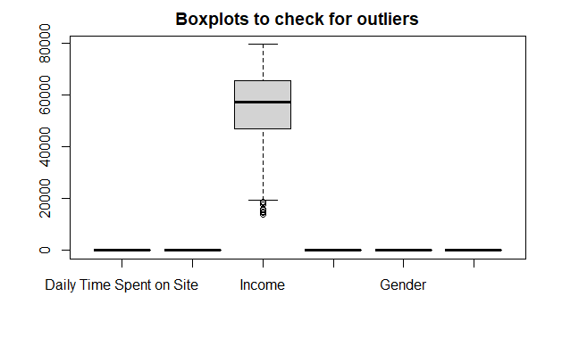

```r
#Checking for outliers
Time_spent = df$Daily.Time.Spent.on.Site
Age = df$Age
Income = df$Area.Income
Internet = df$Daily.Internet.Usage
Gender = df$Gender
Clicked = df$Clicked.on.Ad

boxplot(Time_spent, Age, Income, Internet, Gender, Clicked, main = "Boxplots to check for outliers",   names = c("Daily Time Spent on Site", "Age", "Income","Daily Internet Usage", "Gender","Clicked on ad"), vertical = TRUE)
```

There are significant outliers in income column. These exist in real life and so we are going to ignore them. Dropping them might lead to loss of vital information.

#### Feature Engineering

We can get the month from the date and use it to perform EDA

```r
#create a new column to hold the months
df$Month <- months(df$Timestamp)
head(df)
```

|  | Daily.Time.Spent.on.Site | Age | Area.Income | Daily.Internet.Usage | Ad.Topic.Line | City | Gender | Country | Timestamp | Clicked.on.Ad | Month |
| --- | --- | --- | --- | --- | --- | --- | --- | --- | --- | --- | --- |
| 1 | 68.95 | 35 | 61833.90 | 256.09 | Cloned 5thgeneration orchestration | Wrightburgh | 0 | Tunisia | 2016-03-27 | 0 | March |
| 2 | 80.23 | 31 | 68441.85 | 193.77 | Monitored national standardization | West Jodi | 1 | Nauru | 2016-04-04 | 0 | April |
| 3 | 69.47 | 26 | 59785.94 | 236.50 | Organic bottom-line service-desk | Davidton | 0 | San Marino | 2016-03-13 | 0 | March |
| 4 | 74.15 | 29 | 54806.18 | 245.89 | Triple-buffered reciprocal time-frame | West Terrifurt | 1 | Italy | 2016-01-10 | 0 | January |
| 5 | 68.37 | 35 | 73889.99 | 225.58 | Robust logistical utilization | South Manuel | 0 | Iceland | 2016-06-03 | 0 | June |
| 6 | 59.99 | 23 | 59761.56 | 226.74 | Sharable client-driven software | Jamieberg | 1 | Norway | 2016-05-19 | 0 | May |

```r
NA
```

## Exploratory Data Analysis

### Univariate Analysis

#### Mean

|  | Daily.Time.Spent.on.Site | Age | Area.Income | Daily.Internet.Usage | Gender | Clicked.on.Ad |
| --- | --- | --- | --- | --- | --- | --- |
| 1 | 68.95 | 35 | 61833.90 | 256.09 | 0 | 0 |
| 2 | 80.23 | 31 | 68441.85 | 193.77 | 1 | 0 |
| 3 | 69.47 | 26 | 59785.94 | 236.50 | 0 | 0 |
| 4 | 74.15 | 29 | 54806.18 | 245.89 | 1 | 0 |
| 5 | 68.37 | 35 | 73889.99 | 225.58 | 0 | 0 |
| 6 | 59.99 | 23 | 59761.56 | 226.74 | 1 | 0 |

```r
#find the mean
colMeans(df_num)
```

```
Daily.Time.Spent.on.Site                      Age              Area.Income
                 65.0002                  36.0090               55000.0001
    Daily.Internet.Usage                   Gender            Clicked.on.Ad
                180.0001                   0.4810                   0.5000
```

#### mode

```r
mode_func <- function(my_value){
  uniq_value <- unique(my_value)
  uniq_value[which.max(tabulate(match(my_value,uniq_value)))]
}

message("The mode of time spent on site: " , as.character(mode_func(df$Daily.Time.Spent.on.Site)))
```

```
The mode of time spent on site: 62.26
```

```r
message("The mode of Age: ",as.character(mode_func(df$Age)))
```

```
The mode of Age: 31
```

```r
message("The mode of Area income: " ,as.character(mode_func(df$Area.Income)))
```

```
The mode of Area income: 61833.9
```

```r
message("The mode of Daily Internet Usage: ", as.character(mode_func(df$Daily.Internet.Usage)))
```

```
The mode of Daily Internet Usage: 167.22
```

```r
message("The mode of City: ",as.character(mode_func(df$City)))
```

```
The mode of City: Lisamouth
```

```r
message("The mode of Gender: ", as.character(mode_func(df$Gender)))
```

```
The mode of Gender: 0
```

```r
message("The mode of Country: ", as.character(mode_func(df$Country)))
```

```
The mode of Country: Czech Republic
```

```r
message("The mode of Clicked on Ad: ", as.character(mode_func(df$Clicked.on.Ad)))
```

```
The mode of Clicked on Ad: 0
```

```r
message("The mode of Month: ", as.character(mode_func(df$Month)))
```

```
The mode of Month: February
```

#### plots

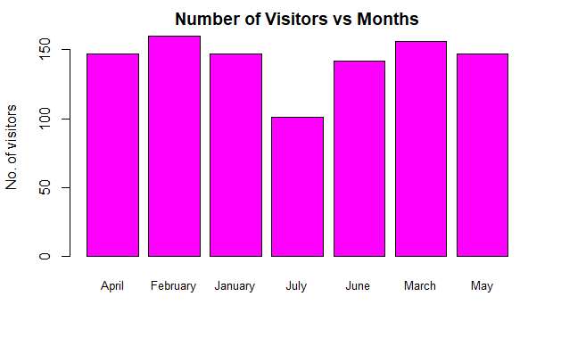

```r
#show how many visitors were across the months
barplot(table(df$Month), main = "Number of Visitors vs Months", ylab = "No. of visitors", col ="magenta", cex.names = 0.8)
```

From the barplot above we see that February had the highest number of traffic followed by March. July had the least visitors

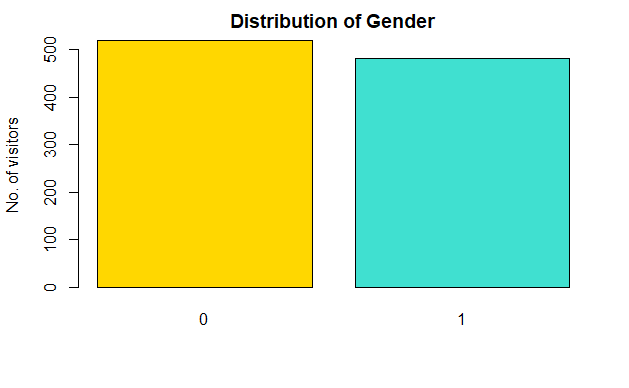

```r
barplot(table(df$Gender),  col =  c("gold" , "turquoise"), ylab = "No. of visitors", main = "Distribution of Gender")
```

### Bivariate Analysis

[figure not shown]

The following was our analysis for the correlation plot.

1. The is a high negative correlation between the daily time spent on site and clicking on the ads. This shows that the more time people spend time on ads the less they are likely to click on it
2. The is a medium positive correlation between age and people who clicked on ads. Hence the older the visitor the more likely chance it is for them to click on the ads.
3. There is medium positive correlation between the someones daily internet usage and daily time spent on the site. This means that the the amount of time spent of the site is related to his/her daily internet usage
4. There is a medium negative relationship between one’s income and whether they clicked on an ad. Thus, the higher one’s income, the less likely they are to click on ad.

### Conclusion

From the study the following are my conclusions

- The most time spent on the site is 62.26 and the most popular age of the visitors is 31 years
- Lisamouth is the city with the most vistors while Czech Republic is the country with many visitors
- The users of the website are likely to click on ads if they are of old age or if they spend a little time on the site.
- Most of the visitors were female and February had the most traffic

### Recommendation

From the data analysis done, i would recommend my client to deploy ads that are more of the field she is working on i.e she should put up ads related to courses on cryptocurrency as it would attract the visitors comming for that specific content.